# Practical Machine Learning Project

Scott D. Weitzenhoffer

February 5, 2018

## Data Cleaning

Load the [Human Activity Recognition](http://groupware.les.inf.puc-rio.br/har) dataset:

```r
urlTrain <- "https://d396qusza40orc.cloudfront.net/predmachlearn/pml-training.csv"
urlQuiz <- "https://d396qusza40orc.cloudfront.net/predmachlearn/pml-testing.csv"
training <- read.csv(url(urlTrain))
quiz <- read.csv(url(urlQuiz))
```

`training` has dimension (19622, 160); `quiz` has dimension (20, 160).

Running `View(quiz)`, it appears many columns are all NA. Let’s see if this is true in `training`:

```r
numNATraining <- sapply(training, function(y) sum(is.na(y)))
numNAQuiz <- sapply(quiz, function(y) sum(is.na(y)))
```

Many columns have 19216 NAs; the rest nave no NAs. Let’s get only the columns that have no NAs:

```r
colsTraining <- names(numNATraining[numNATraining == 0])
colsQuiz <- names(numNAQuiz[numNAQuiz == 0])
```

`training` has 93 non-NA columns, and `quiz` has 60 non-NA columns.

Which columns of `quiz` don’t overlap with `training`?

```r
colsQuiz[!(colsQuiz %in% colsTraining)]
```

```
## [1] "problem_id"
```

Only “problem_id” is missing, which makes sense.

The columns of `training` that do overlap with `quiz` (plus “classe”) are the only ones we should investigate, since the rest aren’t in `quiz`.

```r
cols <-colsTraining[(colsTraining %in% colsQuiz)]
training.raw <- training[, c(cols, "classe")]
quiz <- quiz[, colsQuiz]
```

Check for constant variables in `training.raw` by classe:

```r
for (classe in unique(training.raw$classe)) {
    no_var <- sapply(training.raw[training.raw$classe == classe, 8:59],
                     function(x) {all(duplicated(x)[-1L])})
    print(c(classe, names(training.raw[, 8:59])[no_var]))
}
```

```
## [1] "A"
## [1] "B"
## [1] "C"
## [1] "D"
## [1] "E"
```

All good there. How about by user_name?

```r
for (username in unique(training.raw$user_name)) {
    no_var <- sapply(training.raw[training.raw$user_name == username, 8:59],
                     function(x) {all(duplicated(x)[-1L])})
    print(c(username, names(training.raw[, 8:59])[no_var]))
}
```

```
## [1] "carlitos"
## [1] "pedro"
## [1] "adelmo"        "roll_forearm"  "pitch_forearm" "yaw_forearm"
## [1] "charles"
## [1] "eurico"
## [1] "jeremy"    "roll_arm"  "pitch_arm" "yaw_arm"
```

Let’s try to impute the missing values by modeling them from the other data. First, “adelmo” and “roll_forearm”, “pitch_forearm”, “yaw_forearm”: we can probably model these from the remaining forearm variables.

```r
library(caret)
cols <- c("total_accel_forearm",
          "gyros_forearm_x", "gyros_forearm_y", "gyros_forearm_z",
          "accel_forearm_x", "accel_forearm_y", "accel_forearm_z",
          "magnet_forearm_x", "magnet_forearm_y", "magnet_forearm_z")
x <- training.raw[training.raw$user_name != "adelmo", cols]

for (val in c("roll_forearm", "pitch_forearm", "yaw_forearm")) {
    y <- training.raw[training.raw$user_name != "adelmo", val]
    pred <- predict(train(y=y, x=x, method="lm"),
                    training.raw[training.raw$user_name == "adelmo", cols])
    training.raw[training.raw$user_name == "adelmo", val] <- pred
}
```

Similarly for “jeremy” and “roll_arm”, “pitch_arm”, “yaw_arm”: we can probably model these from the remaining arm variables.

```r
cols <- c("total_accel_arm",
          "gyros_arm_x", "gyros_arm_y", "gyros_arm_z",
          "accel_arm_x", "accel_arm_y", "accel_arm_z",
          "magnet_arm_x", "magnet_arm_y", "magnet_arm_z")
x <- training.raw[training.raw$user_name != "jeremy", cols]

for (val in c("roll_arm", "pitch_arm", "yaw_arm")) {
    y <- training.raw[training.raw$user_name != "jeremy", val]
    pred <- predict(train(y=y, x=x, method="lm"),
                    training.raw[training.raw$user_name == "jeremy", cols])
    training.raw[training.raw$user_name == "jeremy", val] <- pred
}
```

Split `training.raw` into `training` and `testing` sets:

```r
set.seed(33733)

inTrain <- createDataPartition(training.raw$classe, p = 3/4)[[1]]
training <- training.raw[ inTrain, ]
testing <- training.raw[-inTrain, ]
```

## Exploratory Data Analysis

Subset training for one subject:

```r
sub1 <- subset(training, user_name == "adelmo")[, 8:60]
```

The names include measurements from “belt”, “arm”, “dumbbell”, and “forearm”. Let’s try clustering by these broad measurement categories.

```r
for (var in c("belt", "arm", "dumbbell", "forearm")) {
    colsClust <- colsTraining[grepl(paste0("_", var, "_"), colsTraining)]

    mdist <- dist(sub1[, colsClust])
    hclustering <- hclust(mdist)

    source("myplclust.R")
    print(paste0("Cluster by ", var))
    myplclust(hclustering, lab.col=unclass(sub1$classe))
    legend("topright", pch=19, col=unique((unclass(sub1$classe))),
           legend=levels(sub1$classe))
}
```

```
## [1] "Cluster by belt"
```

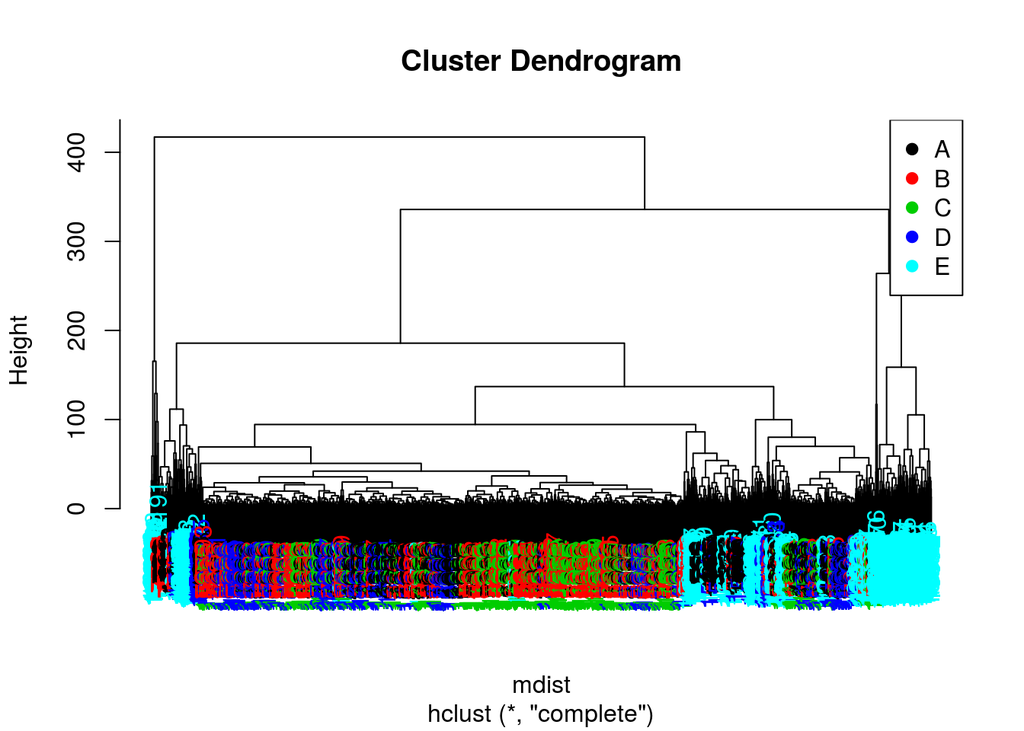

```
## [1] "Cluster by arm"
```

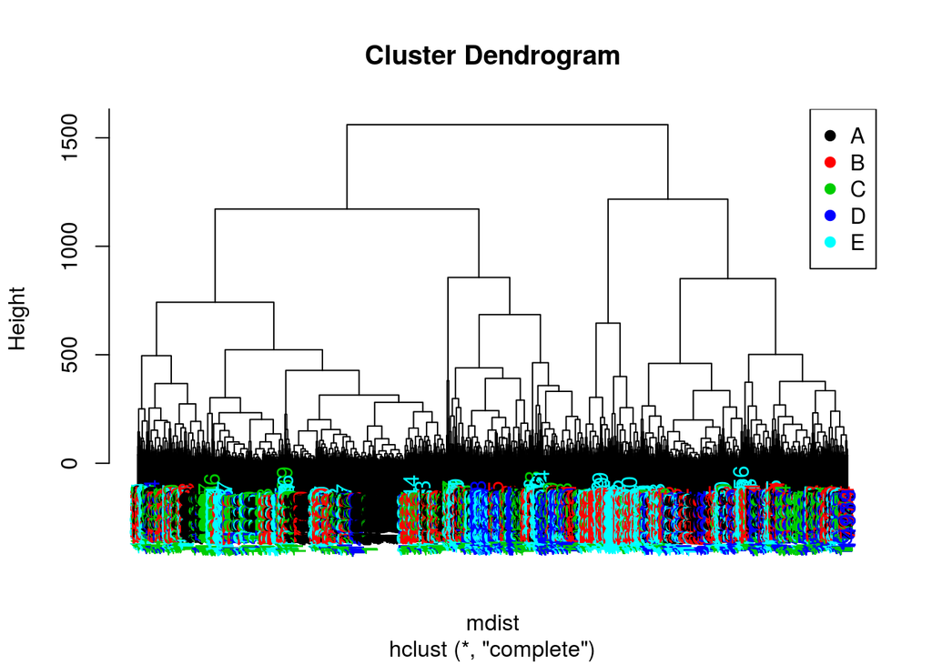

```
## [1] "Cluster by dumbbell"
```

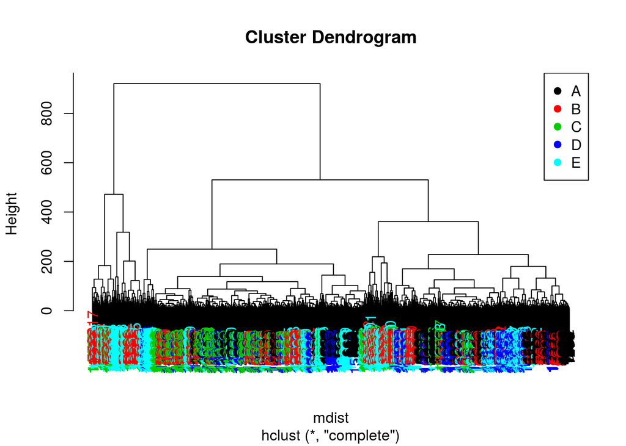

```
## [1] "Cluster by forearm"
```

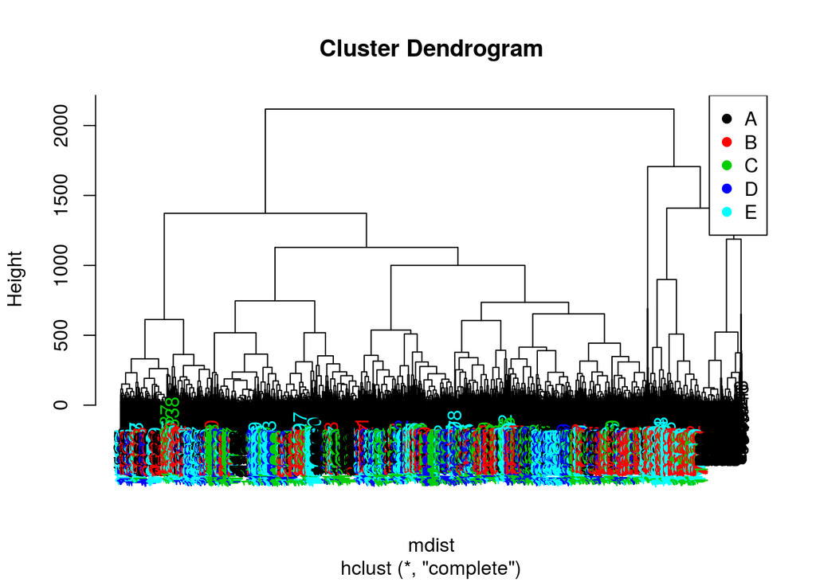

Well, that wasn’t helpful. Rather than mucking around with SVD and the like, let’s just build a Random Forest model to predict classe on user_name and the other likely predictive variables. (i.e, we will exclude X, timestamps, and windows)

## Building the model

First, we’ll configure parallel processing, as outlined in [lgreski’s github page](https://github.com/lgreski/datasciencectacontent/blob/master/markdown/pml-randomForestPerformance.md):

```r
library(parallel)
library(doParallel)
cluster <- makeCluster(detectCores() - 1) # convention to leave 1 core for OS
registerDoParallel(cluster)

fitControl <- trainControl(method = "cv",
                           number = 5,
                           allowParallel = TRUE)
```

Fit the model. We exclude columns that won’t aid prediction:

```r
modFit <- train(
    classe ~ .,
    data=training[, c(2, 8:60)],
    method="rf",
    trControl=fitControl
)
```

De-register the parallel processing cluster:

```r
stopCluster(cluster)
registerDoSEQ()
```

## Results

Check model accuracy against `training`:

```r
pred <- predict(modFit, training[, c(2, 8:59)])
confusionMatrix(training$classe, pred)
```

```
## Confusion Matrix and Statistics
##
##           Reference
## Prediction    A    B    C    D    E
##          A 4185    0    0    0    0
##          B    0 2848    0    0    0
##          C    0    0 2567    0    0
##          D    0    0    0 2412    0
##          E    0    0    0    0 2706
##
## Overall Statistics
##
##                Accuracy : 1
##                  95% CI : (0.9997, 1)
##     No Information Rate : 0.2843
##     P-Value [Acc > NIR] : < 2.2e-16
##
##                   Kappa : 1
##  Mcnemar's Test P-Value : NA
##
## Statistics by Class:
##
##                      Class: A Class: B Class: C Class: D Class: E
## Sensitivity            1.0000   1.0000   1.0000   1.0000   1.0000
## Specificity            1.0000   1.0000   1.0000   1.0000   1.0000
## Pos Pred Value         1.0000   1.0000   1.0000   1.0000   1.0000
## Neg Pred Value         1.0000   1.0000   1.0000   1.0000   1.0000
## Prevalence             0.2843   0.1935   0.1744   0.1639   0.1839
## Detection Rate         0.2843   0.1935   0.1744   0.1639   0.1839
## Detection Prevalence   0.2843   0.1935   0.1744   0.1639   0.1839
## Balanced Accuracy      1.0000   1.0000   1.0000   1.0000   1.0000
```

Check model accuracy against `testing`:

```r
pred <- predict(modFit, testing[, c(2, 8:59)])
confusionMatrix(testing$classe, pred)
```

```
## Confusion Matrix and Statistics
##
##           Reference
## Prediction    A    B    C    D    E
##          A 1395    0    0    0    0
##          B    6  939    4    0    0
##          C    0   11  842    2    0
##          D    0    0    8  794    2
##          E    0    1    0    2  898
##
## Overall Statistics
##
##                Accuracy : 0.9927
##                  95% CI : (0.9899, 0.9949)
##     No Information Rate : 0.2857
##     P-Value [Acc > NIR] : < 2.2e-16
##
##                   Kappa : 0.9907
##  Mcnemar's Test P-Value : NA
##
## Statistics by Class:
##
##                      Class: A Class: B Class: C Class: D Class: E
## Sensitivity            0.9957   0.9874   0.9859   0.9950   0.9978
## Specificity            1.0000   0.9975   0.9968   0.9976   0.9993
## Pos Pred Value         1.0000   0.9895   0.9848   0.9876   0.9967
## Neg Pred Value         0.9983   0.9970   0.9970   0.9990   0.9995
## Prevalence             0.2857   0.1939   0.1741   0.1627   0.1835
## Detection Rate         0.2845   0.1915   0.1717   0.1619   0.1831
## Detection Prevalence   0.2845   0.1935   0.1743   0.1639   0.1837
## Balanced Accuracy      0.9979   0.9924   0.9914   0.9963   0.9985
```

This looks good enough, so predict against `quiz`:

```r
pred <- predict(modFit, quiz[, c(2, 8:59)])
data.frame(problem_id=quiz$problem_id, prediction=as.factor(pred))
```

```
##    problem_id prediction
## 1           1          B
## 2           2          A
## 3           3          B
## 4           4          A
## 5           5          A
## 6           6          E
## 7           7          D
## 8           8          B
## 9           9          A
## 10         10          A
## 11         11          B
## 12         12          C
## 13         13          B
## 14         14          A
## 15         15          E
## 16         16          E
## 17         17          A
## 18         18          B
## 19         19          B
## 20         20          B
```